# Molusco abalone - O retorno

Gabriel de Jesus Pereira

2024-03-26

# Introdução

## O que são os abalones

- É um molusco gastrópode, podendo ser pequeno ou grande;
- Servem como alimento e joias para os seres humanos, sendo a China o principal consumidor

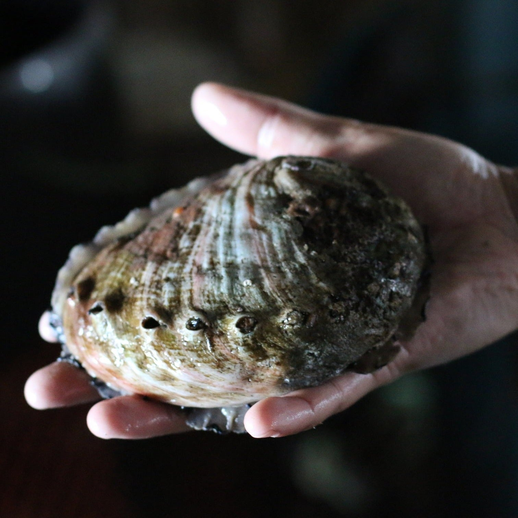

## Sobre o banco de dados

- É um banco de dados da área de biologia que contém medidas físicas de um abalone;
- O banco de dados contém 4177 observações;
- 8 colunas, sendo uma delas nominal e o restante numérica;
- Foi criado por Warwick Nash, Tracy Sellers, Simon Talbot, Andrew Cawthorn, Wes Ford.

## As variáveis do banco de dados

- Peso inteiro do abalone
- Peso da carne do abalone
- Peso das vísceras
- Peso da concha sem carne

# Objetivo

Utilizar técnicas de classificação hierárquica, não-hierárquica e agrupamento paramétrico com dados de moluscos abalone.

# Leitura dos dados

```r
data <- readr::read_csv("abalone.csv") |>
  mutate(
    Sex = case_when(
      Sex == "F" ~ "Fêmea",
      Sex == "M" ~ "Macho",
      TRUE ~ "Filhote"
      )
    ) |>
  select(- Rings)
```

# Análise exploratória

## Distribuições

- Código
- Distribuição

```r
data <- data |>
  (\(x) {
     scaled <- x |>
       select_if(is.numeric) |>
       scale() |>
       as_tibble()

     x |>
       select_if(is.character) |>
       cbind(scaled)
  })()

Distribuição <- data |>
  pivot_longer(
    !Sex,
    names_to = "variable",
    values_to = "values"
  ) |>
  ggplot(
    aes(
      x = values,
      fill = Sex
      )
    ) +
  geom_violin(
    aes(y = variable),
    draw_quantiles = c(0.25, 0.5, 0.75),
    ) +
  labs(x = "", y = "") +
  facet_wrap(vars(variable), scales = "free") +
  scale_fill_manual(
    values = viridis::mako(5)[3:5],
    name = "Sexo"
    ) +
  theme_bw() +
  theme(axis.text.y = element_blank())
```

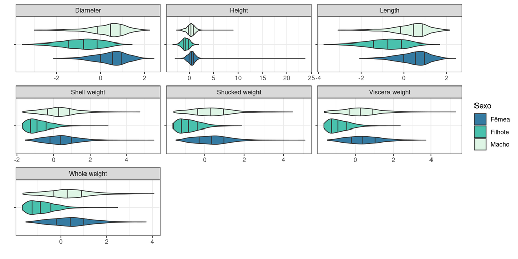

## Distribuições

# Classificação Hierárquica

## Seleção do método

- Código
- Resultados dos métodos

```r
Métodos <- c(
  "average", "single",
  "complete", "ward"
  )

Resultados <- tibble(
  Método = Métodos,
  Critério = rep(0, length(Métodos))
  )

for (i in 1:length(Métodos)) {
  Resultados[i, 2] <- agnes(data, method = Métodos[i], metric = "euclidian")$ac
}
```

| Método | Critério |
| --- | --- |
| Average | 0.9866 |
| Single | 0.9829 |
| Complete | 0.9881 |
| Ward | 0.9982 |

## Seleção do método

Podemos ver na tabela que o melhor método foi o Ward, que será o método utilizado para análise inicial dos clusters.

## Dendograma do método Ward

- Código
- Dendograma

```r
CHWard <- agnes(data, method = "ward", metric = "euclidian") |>
  as.hclust()

plotColoredClusters(
    CHWard,
    labs = case_match(
        data$Sex,
        "Macho" ~ "M",
        "Filhote" ~ "P",
        "Fêmea" ~ "F"
    ),
    cols = case_match(
        data$Sex,
        "Macho" ~ "#fdd402",
        "Filhote" ~ "black",
        "Fêmea" ~ "#9ff837"
    ),
    xlab = "",
    ylab = "Distância"
  )
rect.hclust(CHWard, k = 3, border = c("red","red","red"))
```

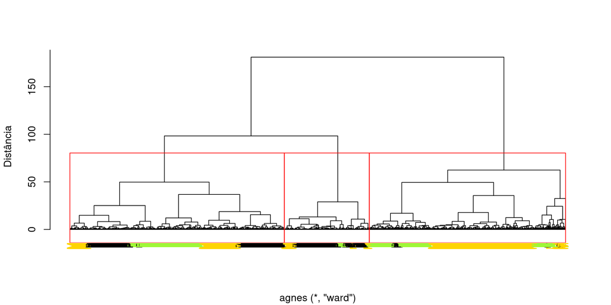

## Dendograma do método Ward

*Os filhotes são representados pelo preto, as fêmeas pelo verde e o macho pelo amarelo.*

Observando o dendrograma, podemos perceber que os filhotes estão bastante concentrados no primeiro e segundo clusters. Ainda, é possível perceber que as classes de sexo de abalone aparecem em distâncias pequenas, mostrando o nível de similaridade entre as classes. Os filhotes apresentam grandes similaridades com a fêmea no primeiro grupo, mas as fêmeas também apresentam similaridades com os machos. As classes apresentam homogeneidade.

## Biplot do método Ward

- Código
- Biplot

```r
Corte3 <- cutree(CHWard , k = 3)
mdados <- data |>
  select_if(is.numeric)
rownames(mdados) <- paste(substr(data$Sex, 1, 2), 1:length(Corte3))

Biplot <- fviz_cluster(
  list(data = mdados, cluster = Corte3, show_labels = FALSE),
  geom = c("point"), repel = TRUE, legend = NULL, shape = NULL) +
  labs(title = "") +
  scale_shape_manual("", values = c(1, 1, 1), guide = "none") +
  scale_color_brewer("", palette = "Set2") +
  scale_fill_brewer("", palette = "Set2", guide = "none") +
  guides(fill = "none")

Biplot +
  geom_point(
    data = Biplot$data |>
      mutate(Sex = data$Sex),
    aes(x = x, y = y, colour = Sex),
    alpha = 0.7,
    size = 2.3
    ) +
  theme_bw()
```

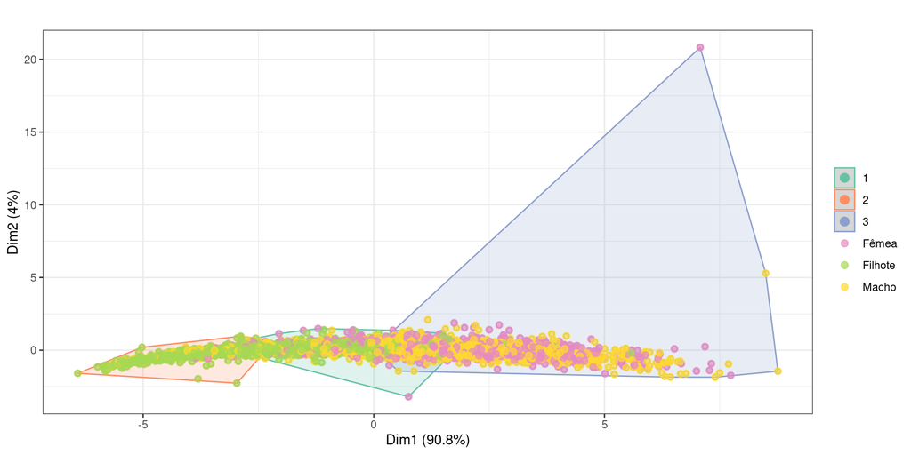

## Biplot do método Ward

Podemos perceber também a homogeneidade entre os filhotes, machos e fêmeas através do biplot do método Ward.

## Tabela de contigência

```r
(table(data.frame(Abalone = data$Sex, Classes = Corte3)) / nrow(data)) |>
  knitr::kable()
```

|  | 1 | 2 | 3 |
| --- | --- | --- | --- |
| Fêmea | 0.1443620 | 0.0131673 | 0.1553747 |
| Filhote | 0.1785971 | 0.1309552 | 0.0117309 |
| Macho | 0.1096481 | 0.0272923 | 0.2288724 |

## Tabela de contigência

Pela tabela vemos que há uma maior frequência de filhotes no primeiro e segundo grupo, talvez sendo aqueles grupos relacionados a menores medidas. Já os machos estão representados mais no terceiro quadrante, podendo se aquele grupo com as maiores medidas.

# Classificação Não-Hierárquica

## K-means

- Código
- Biplot

```r
semente <- round(aggregate(data |> select_if(is.numeric),
                           by = list(cluster = data$Sex), mean)[,-1], 2)
km <- kmeans(data |> select_if(is.numeric), centers = semente)

Biplot <- fviz_cluster(
  list(data = mdados, cluster = km$cluster, show_labels = FALSE),
  geom = c("point"), repel = TRUE, legend = NULL, shape = NULL) +
  labs(title = "") +
  scale_shape_manual("", values = c(1, 1, 1), guide = "none") +
  scale_color_brewer("", palette = "Set2") +
  scale_fill_brewer("", palette = "Set2", guide = "none") +
  guides(fill = "none")

Biplot +
  geom_point(
    data = Biplot$data |>
      mutate(Sex = data$Sex),
    aes(x = x, y = y, colour = Sex),
    alpha = 0.7,
    size = 2.3
    ) +
  theme_bw()
```

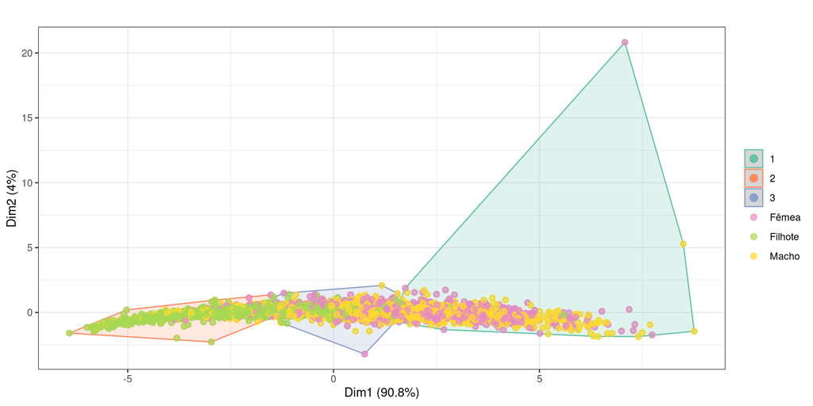

## K-means

Podemos ver pelo K-Means ainda que as classes dos abalones acabam caindo em variados grupos, mostrando mais uma vez a homogeneidade entre as medidas corporais dos abalones.

## Tabela de contigência

```r
(table(data.frame(Abalone = data$Sex, Classes = km$cluster)) / nrow(data)) |>
  knitr::kable()
```

|  | 1 | 2 | 3 |
| --- | --- | --- | --- |
| Fêmea | 0.1333493 | 0.0349533 | 0.1446014 |
| Filhote | 0.0069428 | 0.2073258 | 0.1070146 |
| Macho | 0.1386162 | 0.0557817 | 0.1714149 |

## Tabela de contigência

Diferente da tabela anterior, vemos que existem muitos filhotes classificados no terceiro quadrante, e muitos no segundo quadrante.

# Agrupamento paramétrico

## BIC

- Código
- BIC para cada método

```r
BIC <- mclustBIC(data[,-1])
plot(BIC)
```

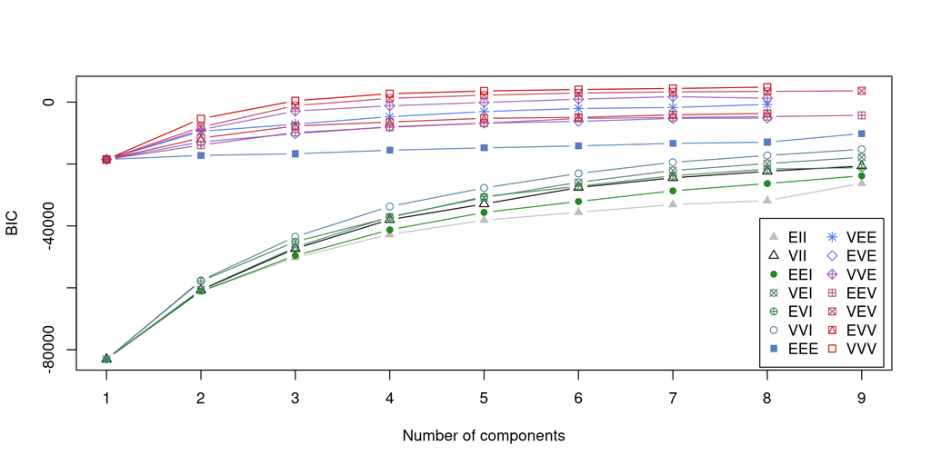

## Biplot com modelo VVV

- Código
- Biplot

```r
Modelo1 <- data |>
  select_if(is.numeric) |>
  Mclust(x = BIC, G = 3)

Biplot <- fviz_cluster(
  list(data = mdados, cluster = Modelo1$classification, show_labels = FALSE),
  geom = c("point"), repel = TRUE, legend = NULL, shape = NULL) +
  labs(title = "") +
  scale_shape_manual("", values = c(1, 1, 1), guide = "none") +
  scale_color_brewer("", palette = "Set2") +
  scale_fill_brewer("", palette = "Set2", guide = "none") +
  guides(fill = "none")

Biplot +
  geom_point(
    data = Biplot$data |>
      mutate(Sex = data$Sex),
    aes(x = x, y = y, colour = Sex),
    alpha = 0.7,
    size = 2.3
    ) +
  theme_bw()
```

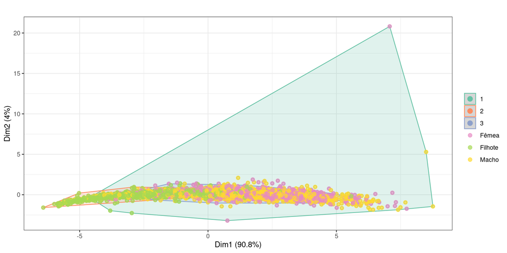

## Tabela de contigência VVV

```r
(table(data.frame(Abalone = data$Sex, Classes = Modelo1$classification)) / nrow(data)) |>
  knitr::kable()
```

|  | 1 | 2 | 3 |
| --- | --- | --- | --- |
| Fêmea | 0.0581757 | 0.0258559 | 0.2288724 |
| Filhote | 0.0098157 | 0.1891310 | 0.1223366 |
| Macho | 0.0598516 | 0.0488389 | 0.2571223 |

## Tabela de contigência VVV

Observando o biplot anteriormente e analisando a tabela de contigência, vemos que o modelo VVV não parece estar classificando bem os abalones.

- Código
- Biplot

```r
Modelo2 <- data |>
  select_if(is.numeric) |>
  Mclust(G=3, modelNames = "EEI")

Biplot <- fviz_cluster(
  list(data = mdados, cluster = Modelo2$classification, show_labels = FALSE),
  geom = c("point"), repel = TRUE, legend = NULL, shape = NULL) +
  labs(title = "") +
  scale_shape_manual("", values = c(1, 1, 1), guide = "none") +
  scale_color_brewer("", palette = "Set2") +
  scale_fill_brewer("", palette = "Set2", guide = "none") +
  guides(fill = "none")

Biplot +
  geom_point(
    data = Biplot$data |>
      mutate(Sex = data$Sex),
    aes(x = x, y = y, colour = Sex),
    alpha = 0.7,
    size = 2.3
    ) +
  theme_bw()
```

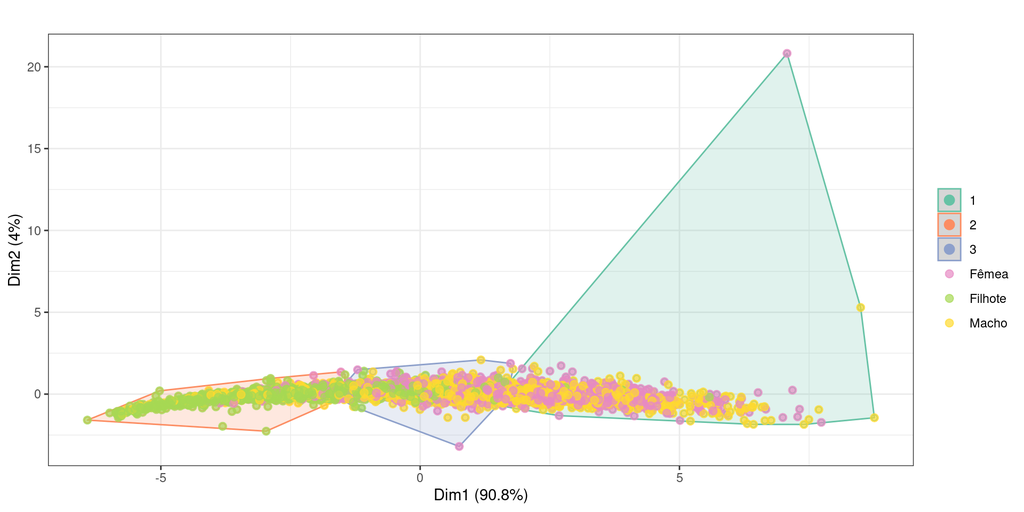

```r
(table(data.frame(Abalone = data$Sex, Classes = Modelo2$classification)) / nrow(data)) |>
  knitr::kable()
```

|  | 1 | 2 | 3 |
| --- | --- | --- | --- |
| Fêmea | 0.1314340 | 0.0335169 | 0.1479531 |
| Filhote | 0.0067034 | 0.2044530 | 0.1101269 |
| Macho | 0.1367010 | 0.0545846 | 0.1745272 |

# Conclusão

Vimos pelo dendrograma e os gráficos biplot que foi possível detectar a similaridade entre os filhotes, fêmeas e machos. Podemos também atráves das tabelas de contigência e biplots, detectar que os filhotes são aqueles com as menores medidas.